# DATA-413/613

Things to Remember II

Hamid Semiyari

2024-06-25

```r
##### klippy is not available from CRAN, but you can install
##### the development version from GitHub with:

# install.packages("remotes")
remotes::install_github("rlesur/klippy")
```

# 1 Functions

  ```r
  # Returns number of positions that have an NA in both positions of two vectors.
  #
  # x: A vector the same length as y
  # y: A vector the same length as x
  #
  # returns: The number of positions that have an NA in both x and y
  both_na <- function(x, y) {
    stopifnot(length(x) == length(y))
    return(sum(is.na(x) & is.na(y)))
  }
  both_na(c(1, NA, 2), c(NA, NA, 2))
  ```

  ```
  ## [1] 1
  ```

  ```r
  both_na(c(NA, NA, 2), c(NA, NA, 2))
  ```

  ```
  ## [1] 2
  ```

  ```r
  both_na(c(NA, NA, NA), c(NA, NA, 2))
  ```

  ```
  ## [1] 2
  ```

```r
na_both <- function(x, y){
  if (length(x) == length(y)){
    na <- sum(is.na(x) & is.na(y))
  } else {
    na <- "No match"
  }
  na
}
    na_both(c(1, NA, 2), c(NA, NA, 2))
```

```
## [1] 1
```

```r
    na_both(c(NA, NA, 2), c(NA, NA, 2))
```

```
## [1] 2
```

```r
    na_both(c(NA, NA, NA), c(NA, NA, 2))
```

```
## [1] 2
```

```r
    na_both(c(NA, NA, NA), c(NA, NA, 2, 1))
```

```
## [1] "No match"
```

# 2 Conditional Execution

- Conditional if-then statements are useful to evaluate code only if certain conditions are met. The syntax is:

```r
    if (condition) {
      # code executed when condition is TRUE
    } else {
      # code executed when condition is FALSE
    }
```

```r
    # input: x a numeric
    # output: TRUE if x > 0, FALSE if x <= 0
    is_positive <- function(x) {
      if (x > 0) {
        pos_logic <- TRUE
      } else {
        pos_logic <- FALSE
      }
      return(pos_logic)
    }

    is_positive(10)
```

```
## [1] TRUE
```

```r
    is_positive(-1)
```

```
## [1] FALSE
```

```r
    is_positive(0.1)
```

```
## [1] TRUE
```

- **Exercise**: Implement a `fizzbuzz()` function. It takes a single number as input. If the number is divisible by three, it returns `"fizz"`. If it’s divisible by five it returns `"buzz"`. If it’s divisible by three and five, it returns `"fizzbuzz"`. Otherwise, it returns the number. Make sure you first write working code before you create the function.

```r
    fizzbuzz <- function(x) {
      is3 <- x %% 3 == 0
      is5 <- x %% 5 == 0
      if (is3 && is5) {
        return("fizzbuzz")
      } else if (is3) {
        return("fizz")
      } else if (is5) {
        return("buzz")
      } else {
        return(x)
      }
    }

    fizzbuzz(3)
```

```
## [1] "fizz"
```

```r
    fizzbuzz(5)
```

```
## [1] "buzz"
```

```r
    fizzbuzz(15)
```

```
## [1] "fizzbuzz"
```

```r
    fizzbuzz(2)
```

```
## [1] 2
```

```r
output <- 0
fzbz <- function(x){
  x <- x[!is.na(x)]
  if (length(x) <=1){
    x <-c(x)
  } else {x <- x}
  for (i in 1:length(x)){

  if (x[i]%%3==0 & x[i]%%5==0) {
    output[i] <- "fizzbuzz"
  } else if (x[i]%%3 == 0) {
    output[i] <- "fizz"
  } else if (x[i]%%5 ==0) {
    output[i] <- "buzz"
  } else {
       output[i] <- x[i]
      }
}
output
}
fzbz(15)
```

```
## [1] "fizzbuzz"
```

```r
fzbz(3)
```

```
## [1] "fizz"
```

```r
fzbz(5)
```

```
## [1] "buzz"
```

```r
fzbz(c(15, 3, 2, NA))
```

```
## [1] "fizzbuzz" "fizz"     "2"
```

# 3 Visualization

- A **grammar of graphics** is a grammar used to describe and create a wide range of statistical graphics.
- **Aesthetic** means “something you can see”. The aesthetic attributes consists of color, size, and shape. Aesthetic mappings describe how variables in the data are mapped to visual properties (aesthetics) of geoms (geometric of objects). In summary, The ggplot2 helps you to display your data in R. A geom defines the layout of a ggplot2 layer. So, a geoms help you to create histogram, bar charts, or any other plots.

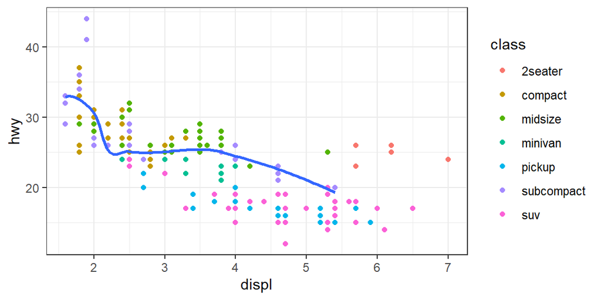

```r
ggplot(data = mpg, mapping = aes(x = displ, y = hwy)) +
  geom_point(mapping = aes(color = class)) +
  geom_smooth(data = filter(mpg, class == "subcompact"),
              se = FALSE)
```

- FACET a Single Variable  
  Please note the ~ before the name of variable in the first argument of `facet_wrap(,)` Also the variable must be discrete (or categorical)

```r
library(tidyverse)
```

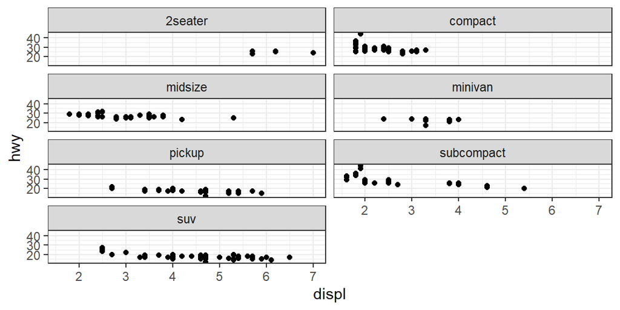

```r
# A categorical variable (class)

ggplot(data = mpg) +
  geom_point(mapping = aes(x = displ, y = hwy)) +
             facet_wrap(~ class, ncol=2 )
```

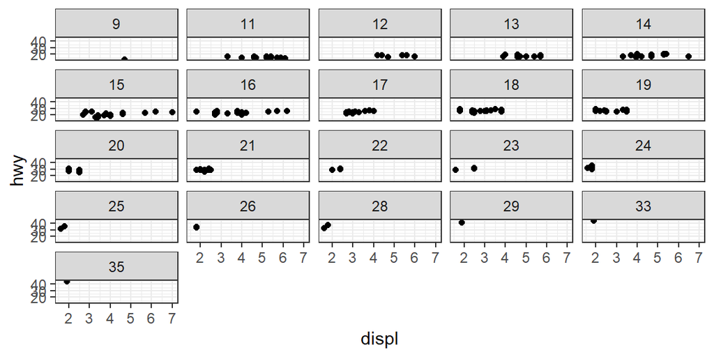

```r
# A Discrete variable (cty)
ggplot(data = mpg) +
  geom_point(mapping = aes(x = displ, y = hwy)) +
  facet_wrap(~ cty, nrow = 5)
```

- FACET on the combination of two variables

Please note the ~ between the name of variables in the argument of `facet_grid(,)`

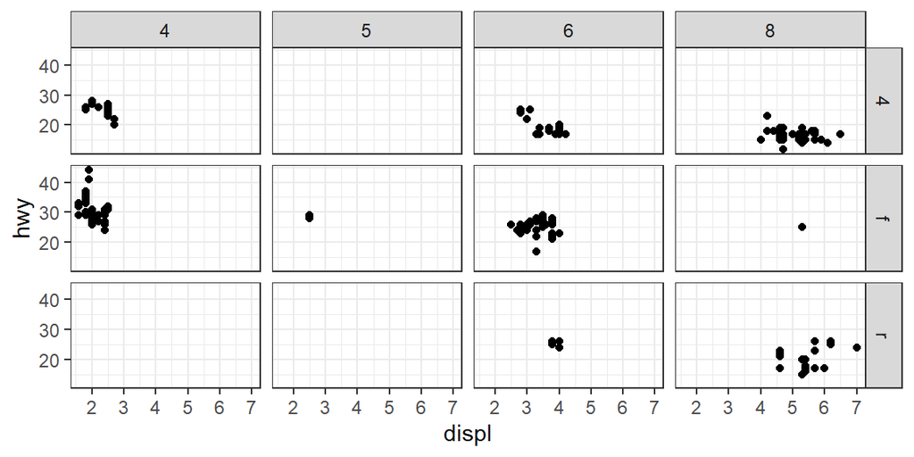

```r
ggplot(data = mpg) +
  geom_point(mapping = aes(x = displ, y = hwy)) +
  facet_grid(drv ~ cyl)
```

- When using `facet_grid()` you should usually put the # variable with more unique levels in the columns. why?

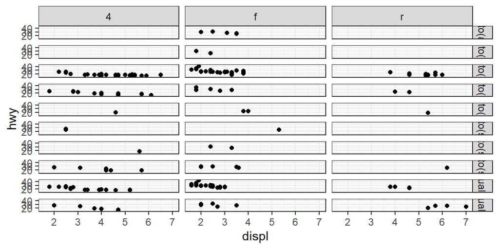

```r
ggplot(data = mpg) +
  geom_point(mapping = aes(x = displ, y = hwy)) +
  facet_grid(trans ~ drv)
```

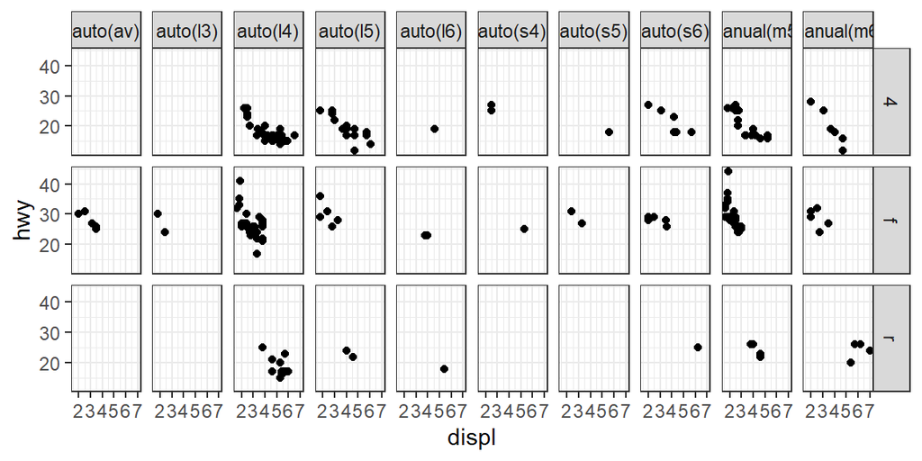

```r
# See the difference

ggplot(data = mpg) +
  geom_point(mapping = aes(x = displ, y = hwy)) +
  facet_grid(drv ~ trans)
```

## 3.1 WE CAN HAVE ALL IN ONE CODE

You need to install and load `cowplot` package

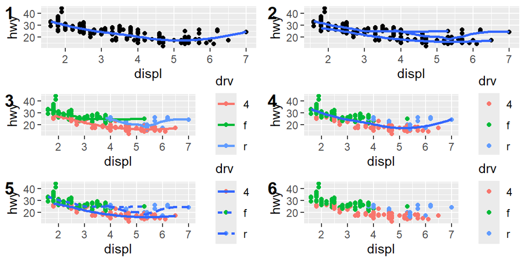

```r
p1 <- ggplot(data = mpg, mapping = aes(x = displ, y = hwy)) +
  geom_point() +
  geom_smooth(se = FALSE)
p2 <- ggplot(data = mpg, mapping = aes(x = displ, y = hwy)) +
  geom_point() +
  geom_smooth(mapping = aes(group = drv), se = FALSE)
p3 <- ggplot(data = mpg, mapping = aes(x = displ, y = hwy,
                                       color=drv)) +
  geom_point() +
  geom_smooth(se = FALSE)
p4 <- ggplot(data = mpg, mapping = aes(x = displ, y = hwy)) +
  geom_point(mapping = aes(color=drv)) +
  geom_smooth(se = FALSE)
p5 <- ggplot(data = mpg, mapping = aes(x = displ, y = hwy)) +
  geom_point(mapping = aes(color=drv)) +
  geom_smooth(se = FALSE, mapping = aes(linetype = drv))
p6 <- ggplot(data = mpg, mapping = aes(x = displ, y = hwy)) +
  geom_point(mapping = aes(color=drv))
theme_set(theme_gray())
plot_grid(p1, p2, p3, p4, p5, p6,
          labels=c("1","2","3", "4","5","6"), ncol=2,
          nrow = 3)
```

# 4 Tidy Data and Tidying Data

- What is tidy data?  
  Organizing your data in R. Once you have tidy data (it requires upfront work, but that work pays off in long term). and the tidy tools provided by packages in the `tidyverse`, you will spend less time munging data (preparing your data for a dedicated purpose) from one representation to another, allowing you to spend more time on the analytic questions at hand.
- Learn to make your data tidy with `gather()`, `spread()`, `separate()`, and `pivot_longer()`, `pivot_wider`. The last two was new and they have been introduced toimprove visibility of `gather()` and `spread()`.
- **Tidy Data**
- Recall:
  - Observations/units/subjects/individuals/cases: objects described by a set of data (e.g. cars, people, countries).
  - Variable: describes some characteristic of the units (e.g. mpg, age, GDP).
  - Each unit has a single value of each variable (e.g. 20 mpg, 31 years old, $20,513,000 US$million).
- Tidy Data:
  - One unit per row.
  - One variable per column.
  - One value per cell.
- Hadley’s visualization:

[figure not shown]

- We will use the tidyr package (a member of the tidyverse) to make data tidy.
- Example of tidy data:

  ```r
  tidyr::table1
  ```

  ```
  ## # A tibble: 6 × 4
  ##   country      year  cases population
  ##   <chr>       <dbl>  <dbl>      <dbl>
  ## 1 Afghanistan  1999    745   19987071
  ## 2 Afghanistan  2000   2666   20595360
  ## 3 Brazil       1999  37737  172006362
  ## 4 Brazil       2000  80488  174504898
  ## 5 China        1999 212258 1272915272
  ## 6 China        2000 213766 1280428583
  ```

  - Variables: Country, Year, Cases, Population
  - Units: location$\times$time
- Untidy data: Each unit is spread across multiple rows

```r
    print(tidyr::table2, n = 12)
```

```
## # A tibble: 12 × 4
##    country      year type            count
##    <chr>       <dbl> <chr>           <dbl>
##  1 Afghanistan  1999 cases             745
##  2 Afghanistan  1999 population   19987071
##  3 Afghanistan  2000 cases            2666
##  4 Afghanistan  2000 population   20595360
##  5 Brazil       1999 cases           37737
##  6 Brazil       1999 population  172006362
##  7 Brazil       2000 cases           80488
##  8 Brazil       2000 population  174504898
##  9 China        1999 cases          212258
## 10 China        1999 population 1272915272
## 11 China        2000 cases          213766
## 12 China        2000 population 1280428583
```

- Untidy data: Two variables are in one column

```r
    tidyr::table3
```

```
## # A tibble: 6 × 3
##   country      year rate
##   <chr>       <dbl> <chr>
## 1 Afghanistan  1999 745/19987071
## 2 Afghanistan  2000 2666/20595360
## 3 Brazil       1999 37737/172006362
## 4 Brazil       2000 80488/174504898
## 5 China        1999 212258/1272915272
## 6 China        2000 213766/1280428583
```

- Untidy data: Data are spread across two data frames. Within each data frame, multiple units are in one row.

```r
    tidyr::table4a
```

```
## # A tibble: 3 × 3
##   country     `1999` `2000`
##   <chr>        <dbl>  <dbl>
## 1 Afghanistan    745   2666
## 2 Brazil       37737  80488
## 3 China       212258 213766
```

```r
    tidyr::table4b
```

```
## # A tibble: 3 × 3
##   country         `1999`     `2000`
##   <chr>            <dbl>      <dbl>
## 1 Afghanistan   19987071   20595360
## 2 Brazil       172006362  174504898
## 3 China       1272915272 1280428583
```

- Sometimes it is easy to determine the units and the variables.
- Sometimes it is very hard and you need to talk to the data collectors to find out.
- We want tidy data because R easily manipulates vectors. So in the long run it will make your life easier to first make data tidy.

## 4.1 `pivot_longer()` and `gather()`

- An updated approach to `gather()` is `pivot_longer()`. It “lengthens” data, increasing the number of rows and decreasing the number of columns. The inverse transformation is `pivot_wider()`
- Problem: One variable spread across multiple columns.
- Column names are actually *values* of a variable
- `table4a` and `table4b`
- Solution: `gather()`
- Hadley’s visualization:

[figure not shown]

- Specify
  1. The columns that are values, not variables,
  2. The name of the variable that will take the values of the column names (`key`), and
  3. The name of the variable that will take the values spread in the cells

```r
table4b
```

```
## # A tibble: 3 × 3
##   country         `1999`     `2000`
##   <chr>            <dbl>      <dbl>
## 1 Afghanistan   19987071   20595360
## 2 Brazil       172006362  174504898
## 3 China       1272915272 1280428583
```

```r
    tidyr::table4a %>%
      gather(`1999`, `2000`, key = "Year", value = "cases") ->
      tidy4a1
    tidy4a1
```

```
## # A tibble: 6 × 3
##   country     Year   cases
##   <chr>       <chr>  <dbl>
## 1 Afghanistan 1999     745
## 2 Brazil      1999   37737
## 3 China       1999  212258
## 4 Afghanistan 2000    2666
## 5 Brazil      2000   80488
## 6 China       2000  213766
```

```r
    tidyr::table4b %>%
      gather(`1999`, `2000`, key = "Year", value = "population") ->
      tidy4b1
    tidy4b1
```

```
## # A tibble: 6 × 3
##   country     Year  population
##   <chr>       <chr>      <dbl>
## 1 Afghanistan 1999    19987071
## 2 Brazil      1999   172006362
## 3 China       1999  1272915272
## 4 Afghanistan 2000    20595360
## 5 Brazil      2000   174504898
## 6 China       2000  1280428583
```

```r
    tidyr::table4a %>%
      pivot_longer(`1999`: `2000`, names_to  = "Year", values_to = "cases")
```

```
## # A tibble: 6 × 3
##   country     Year   cases
##   <chr>       <chr>  <dbl>
## 1 Afghanistan 1999     745
## 2 Afghanistan 2000    2666
## 3 Brazil      1999   37737
## 4 Brazil      2000   80488
## 5 China       1999  212258
## 6 China       2000  213766
```

```r
    tidyr::table4a %>%
      pivot_longer(!country, names_to  = "Year", values_to = "cases") ->
      tidy4a2
    tidy4a2
```

```
## # A tibble: 6 × 3
##   country     Year   cases
##   <chr>       <chr>  <dbl>
## 1 Afghanistan 1999     745
## 2 Afghanistan 2000    2666
## 3 Brazil      1999   37737
## 4 Brazil      2000   80488
## 5 China       1999  212258
## 6 China       2000  213766
```

```r
    tidyr::table4b %>%
      pivot_longer(c(`1999`,`2000`), names_to = "Year", values_to = "population") ->
      tidy4b2
    tidy4b2
```

```
## # A tibble: 6 × 3
##   country     Year  population
##   <chr>       <chr>      <dbl>
## 1 Afghanistan 1999    19987071
## 2 Afghanistan 2000    20595360
## 3 Brazil      1999   172006362
## 4 Brazil      2000   174504898
## 5 China       1999  1272915272
## 6 China       2000  1280428583
```

- We will learn next class how to join these two data frames next week. But the code is

```r
    full_join(tidy4a2, tidy4b2)
```

```
## # A tibble: 6 × 4
##   country     Year   cases population
##   <chr>       <chr>  <dbl>      <dbl>
## 1 Afghanistan 1999     745   19987071
## 2 Afghanistan 2000    2666   20595360
## 3 Brazil      1999   37737  172006362
## 4 Brazil      2000   80488  174504898
## 5 China       1999  212258 1272915272
## 6 China       2000  213766 1280428583
```

```r
left_join(tidy4a2, tidy4b2)
```

```
## # A tibble: 6 × 4
##   country     Year   cases population
##   <chr>       <chr>  <dbl>      <dbl>
## 1 Afghanistan 1999     745   19987071
## 2 Afghanistan 2000    2666   20595360
## 3 Brazil      1999   37737  172006362
## 4 Brazil      2000   80488  174504898
## 5 China       1999  212258 1272915272
## 6 China       2000  213766 1280428583
```

## 4.2 `pivot_wider()` and `spread()`

`pivot_wider()` is an updated approach to `spread()`. It “widens” data, increasing the number of columns and decreasing the number of rows. The inverse transformation is `pivot_longer()`

- Problem: One observation is spread across multiple rows.
- One column contains variable names. One column contains values for the different variables.
- `table2`
- Solution: `spread()`
- Hadley’s visualization:

[figure not shown]

- Specify:
  1. The column that contains the column names (`key`), and
  2. The column that contains the values (`value`).

```r
tidyr::table2
```

```
## # A tibble: 12 × 4
##    country      year type            count
##    <chr>       <dbl> <chr>           <dbl>
##  1 Afghanistan  1999 cases             745
##  2 Afghanistan  1999 population   19987071
##  3 Afghanistan  2000 cases            2666
##  4 Afghanistan  2000 population   20595360
##  5 Brazil       1999 cases           37737
##  6 Brazil       1999 population  172006362
##  7 Brazil       2000 cases           80488
##  8 Brazil       2000 population  174504898
##  9 China        1999 cases          212258
## 10 China        1999 population 1272915272
## 11 China        2000 cases          213766
## 12 China        2000 population 1280428583
```

```r
    table2 %>%
      spread(key = "type", value = "count")
```

```
## # A tibble: 6 × 4
##   country      year  cases population
##   <chr>       <dbl>  <dbl>      <dbl>
## 1 Afghanistan  1999    745   19987071
## 2 Afghanistan  2000   2666   20595360
## 3 Brazil       1999  37737  172006362
## 4 Brazil       2000  80488  174504898
## 5 China        1999 212258 1272915272
## 6 China        2000 213766 1280428583
```

We get a column for each values of type!

What will happen if I switch type and count?

```r
    table2 %>%
      pivot_wider(names_from = "type", values_from = "count")
```

```
## # A tibble: 6 × 4
##   country      year  cases population
##   <chr>       <dbl>  <dbl>      <dbl>
## 1 Afghanistan  1999    745   19987071
## 2 Afghanistan  2000   2666   20595360
## 3 Brazil       1999  37737  172006362
## 4 Brazil       2000  80488  174504898
## 5 China        1999 212258 1272915272
## 6 China        2000 213766 1280428583
```

## 4.3 `separate()`

- Problem: One column contains two (or more) variables.
- `table3`
- Solution: `separate()`

```r
head(table3)
```

```
## # A tibble: 6 × 3
##   country      year rate
##   <chr>       <dbl> <chr>
## 1 Afghanistan  1999 745/19987071
## 2 Afghanistan  2000 2666/20595360
## 3 Brazil       1999 37737/172006362
## 4 Brazil       2000 80488/174504898
## 5 China        1999 212258/1272915272
## 6 China        2000 213766/1280428583
```

- Hadley’s visualization:

[figure not shown]

- Specify:
  1. The column that contains two (or more) variables,
  2. A character vector of the new names of the variables, and
  3. The character that separates variables (or the position that separates variables).

```r
    table3 %>%
      separate(rate, into = c("cases", "population"), sep = "/")
```

```
## # A tibble: 6 × 4
##   country      year cases  population
##   <chr>       <dbl> <chr>  <chr>
## 1 Afghanistan  1999 745    19987071
## 2 Afghanistan  2000 2666   20595360
## 3 Brazil       1999 37737  172006362
## 4 Brazil       2000 80488  174504898
## 5 China        1999 212258 1272915272
## 6 China        2000 213766 1280428583
```

## 4.4 `unite()`

- Problem: One variable spread across multiple columns.
- Solution: `unite()`
- Hadley’s visualization:

[figure not shown]

- Much less common problem.

```r
    table5
```

```
## # A tibble: 6 × 4
##   country     century year  rate
##   <chr>       <chr>   <chr> <chr>
## 1 Afghanistan 19      99    745/19987071
## 2 Afghanistan 20      00    2666/20595360
## 3 Brazil      19      99    37737/172006362
## 4 Brazil      20      00    80488/174504898
## 5 China       19      99    212258/1272915272
## 6 China       20      00    213766/1280428583
```

- Specify:
  1. The name of the new column (`col`),
  2. The columns to unite, and
  3. The separator of the variables in the new column (`sep`).

```r
    table5 %>%
      unite(century, year, col = "Year", sep = "")
```

```
## # A tibble: 6 × 3
##   country     Year  rate
##   <chr>       <chr> <chr>
## 1 Afghanistan 1999  745/19987071
## 2 Afghanistan 2000  2666/20595360
## 3 Brazil      1999  37737/172006362
## 4 Brazil      2000  80488/174504898
## 5 China       1999  212258/1272915272
## 6 China       2000  213766/1280428583
```

```r
    table5 %>%
      unite(century, year, col = "Year", sep = "") %>%
  mutate(Year = parse_number(Year))
```

```
## # A tibble: 6 × 3
##   country      Year rate
##   <chr>       <dbl> <chr>
## 1 Afghanistan  1999 745/19987071
## 2 Afghanistan  2000 2666/20595360
## 3 Brazil       1999 37737/172006362
## 4 Brazil       2000 80488/174504898
## 5 China        1999 212258/1272915272
## 6 China        2000 213766/1280428583
```

# 5 DPLYR

To explore the basic data manipulation verbs of dplyr, we’ll use `nycflights13::flights`.

- **Question: Sometimes, when I load a new package, I get conflict message. What should I do in this case?**

The conflict message says, your installed package overwrites some function in the base. For instance `dplyr` overwrites some function in base R. such as `filter()`.

- **Question: So, what to do in this case?** If you would like to use filter function in base R. You need to use its full name
  - `package::function`
  - `stats::filter()`

```r
nov_dec <- filter(flights, month %in% c(11, 12))
nov_dec
```

```
## # A tibble: 55,403 × 19
##     year month   day dep_time sched_dep_time dep_delay arr_time sched_arr_time
##    <int> <int> <int>    <int>          <int>     <dbl>    <int>          <int>
##  1  2013    11     1        5           2359         6      352            345
##  2  2013    11     1       35           2250       105      123           2356
##  3  2013    11     1      455            500        -5      641            651
##  4  2013    11     1      539            545        -6      856            827
##  5  2013    11     1      542            545        -3      831            855
##  6  2013    11     1      549            600       -11      912            923
##  7  2013    11     1      550            600       -10      705            659
##  8  2013    11     1      554            600        -6      659            701
##  9  2013    11     1      554            600        -6      826            827
## 10  2013    11     1      554            600        -6      749            751
## # ℹ 55,393 more rows
## # ℹ 11 more variables: arr_delay <dbl>, carrier <chr>, flight <int>,
## #   tailnum <chr>, origin <chr>, dest <chr>, air_time <dbl>, distance <dbl>,
## #   hour <dbl>, minute <dbl>, time_hour <dttm>
```

If you wanted to find flights that weren’t delayed (on arrival or departure) by more than two hours, you could use either of the following two filters:

```r
filter(flights, !(arr_delay > 120 | dep_delay > 120))
```

```
## # A tibble: 316,050 × 19
##     year month   day dep_time sched_dep_time dep_delay arr_time sched_arr_time
##    <int> <int> <int>    <int>          <int>     <dbl>    <int>          <int>
##  1  2013     1     1      517            515         2      830            819
##  2  2013     1     1      533            529         4      850            830
##  3  2013     1     1      542            540         2      923            850
##  4  2013     1     1      544            545        -1     1004           1022
##  5  2013     1     1      554            600        -6      812            837
##  6  2013     1     1      554            558        -4      740            728
##  7  2013     1     1      555            600        -5      913            854
##  8  2013     1     1      557            600        -3      709            723
##  9  2013     1     1      557            600        -3      838            846
## 10  2013     1     1      558            600        -2      753            745
## # ℹ 316,040 more rows
## # ℹ 11 more variables: arr_delay <dbl>, carrier <chr>, flight <int>,
## #   tailnum <chr>, origin <chr>, dest <chr>, air_time <dbl>, distance <dbl>,
## #   hour <dbl>, minute <dbl>, time_hour <dttm>
```

```r
filter(flights, arr_delay <= 120, dep_delay <= 120)
```

```
## # A tibble: 316,050 × 19
##     year month   day dep_time sched_dep_time dep_delay arr_time sched_arr_time
##    <int> <int> <int>    <int>          <int>     <dbl>    <int>          <int>
##  1  2013     1     1      517            515         2      830            819
##  2  2013     1     1      533            529         4      850            830
##  3  2013     1     1      542            540         2      923            850
##  4  2013     1     1      544            545        -1     1004           1022
##  5  2013     1     1      554            600        -6      812            837
##  6  2013     1     1      554            558        -4      740            728
##  7  2013     1     1      555            600        -5      913            854
##  8  2013     1     1      557            600        -3      709            723
##  9  2013     1     1      557            600        -3      838            846
## 10  2013     1     1      558            600        -2      753            745
## # ℹ 316,040 more rows
## # ℹ 11 more variables: arr_delay <dbl>, carrier <chr>, flight <int>,
## #   tailnum <chr>, origin <chr>, dest <chr>, air_time <dbl>, distance <dbl>,
## #   hour <dbl>, minute <dbl>, time_hour <dttm>
```

**A useful short-hand**  
The following expression  
`x %in% y`  
This will select every row where x is one of the values in y `month %in% c(11,12)`  
This will select every row where month is one of the values 11 or 12.

```r
nov_dec <- filter(flights, month %in% c(11, 12))
```

**`filter()` only includes rows where the condition is TRUE;** it excludes both `FALSE` and `NA` values. If you want to preserve missing values, ask for them explicitly:

```r
df <- tibble(x = c(1, NA, 3))
df
```

```
## # A tibble: 3 × 1
##       x
##   <dbl>
## 1     1
## 2    NA
## 3     3
```

```r
filter(df, x > 1)
```

```
## # A tibble: 1 × 1
##       x
##   <dbl>
## 1     3
```

```r
filter(df, is.na(x) | x > 1)
```

```
## # A tibble: 2 × 1
##       x
##   <dbl>
## 1    NA
## 2     3
```

## 5.1 `arrange()`

- `arrange()`: Reorder the rows  
  The `arrange()`, changes rows order. If you provide more than one column name, each additional column will be used to break ties in the values of preceding columns

```r
arrange(flights, year, month, day)
```

```
## # A tibble: 336,776 × 19
##     year month   day dep_time sched_dep_time dep_delay arr_time sched_arr_time
##    <int> <int> <int>    <int>          <int>     <dbl>    <int>          <int>
##  1  2013     1     1      517            515         2      830            819
##  2  2013     1     1      533            529         4      850            830
##  3  2013     1     1      542            540         2      923            850
##  4  2013     1     1      544            545        -1     1004           1022
##  5  2013     1     1      554            600        -6      812            837
##  6  2013     1     1      554            558        -4      740            728
##  7  2013     1     1      555            600        -5      913            854
##  8  2013     1     1      557            600        -3      709            723
##  9  2013     1     1      557            600        -3      838            846
## 10  2013     1     1      558            600        -2      753            745
## # ℹ 336,766 more rows
## # ℹ 11 more variables: arr_delay <dbl>, carrier <chr>, flight <int>,
## #   tailnum <chr>, origin <chr>, dest <chr>, air_time <dbl>, distance <dbl>,
## #   hour <dbl>, minute <dbl>, time_hour <dttm>
```

Use `desc()` to re-order by a column in descending order:

```r
arrange(flights, desc(dep_delay))
```

```
## # A tibble: 336,776 × 19
##     year month   day dep_time sched_dep_time dep_delay arr_time sched_arr_time
##    <int> <int> <int>    <int>          <int>     <dbl>    <int>          <int>
##  1  2013     1     9      641            900      1301     1242           1530
##  2  2013     6    15     1432           1935      1137     1607           2120
##  3  2013     1    10     1121           1635      1126     1239           1810
##  4  2013     9    20     1139           1845      1014     1457           2210
##  5  2013     7    22      845           1600      1005     1044           1815
##  6  2013     4    10     1100           1900       960     1342           2211
##  7  2013     3    17     2321            810       911      135           1020
##  8  2013     6    27      959           1900       899     1236           2226
##  9  2013     7    22     2257            759       898      121           1026
## 10  2013    12     5      756           1700       896     1058           2020
## # ℹ 336,766 more rows
## # ℹ 11 more variables: arr_delay <dbl>, carrier <chr>, flight <int>,
## #   tailnum <chr>, origin <chr>, dest <chr>, air_time <dbl>, distance <dbl>,
## #   hour <dbl>, minute <dbl>, time_hour <dttm>
```

**Question: How missing values take care by arrange()?**  
Missing values are always sorted at the end:

```r
df <- tibble(x = c(5, 2, NA))
arrange(df, x)
```

```
## # A tibble: 3 × 1
##       x
##   <dbl>
## 1     2
## 2     5
## 3    NA
```

```r
arrange(df, desc(x))
```

```
## # A tibble: 3 × 1
##       x
##   <dbl>
## 1     5
## 2     2
## 3    NA
```

## 5.2 `select()`

- `select()`: Pick variables by their names  
  It’s not uncommon to get datasets with hundreds or even thousands of variables. In this case, the first challenge is often narrowing in on the variables you’re actually interested in.

```r
str(flights)
```

```
## tibble [336,776 × 19] (S3: tbl_df/tbl/data.frame)
##  $ year          : int [1:336776] 2013 2013 2013 2013 2013 2013 2013 2013 2013 2013 ...
##  $ month         : int [1:336776] 1 1 1 1 1 1 1 1 1 1 ...
##  $ day           : int [1:336776] 1 1 1 1 1 1 1 1 1 1 ...
##  $ dep_time      : int [1:336776] 517 533 542 544 554 554 555 557 557 558 ...
##  $ sched_dep_time: int [1:336776] 515 529 540 545 600 558 600 600 600 600 ...
##  $ dep_delay     : num [1:336776] 2 4 2 -1 -6 -4 -5 -3 -3 -2 ...
##  $ arr_time      : int [1:336776] 830 850 923 1004 812 740 913 709 838 753 ...
##  $ sched_arr_time: int [1:336776] 819 830 850 1022 837 728 854 723 846 745 ...
##  $ arr_delay     : num [1:336776] 11 20 33 -18 -25 12 19 -14 -8 8 ...
##  $ carrier       : chr [1:336776] "UA" "UA" "AA" "B6" ...
##  $ flight        : int [1:336776] 1545 1714 1141 725 461 1696 507 5708 79 301 ...
##  $ tailnum       : chr [1:336776] "N14228" "N24211" "N619AA" "N804JB" ...
##  $ origin        : chr [1:336776] "EWR" "LGA" "JFK" "JFK" ...
##  $ dest          : chr [1:336776] "IAH" "IAH" "MIA" "BQN" ...
##  $ air_time      : num [1:336776] 227 227 160 183 116 150 158 53 140 138 ...
##  $ distance      : num [1:336776] 1400 1416 1089 1576 762 ...
##  $ hour          : num [1:336776] 5 5 5 5 6 5 6 6 6 6 ...
##  $ minute        : num [1:336776] 15 29 40 45 0 58 0 0 0 0 ...
##  $ time_hour     : POSIXct[1:336776], format: "2013-01-01 05:00:00" "2013-01-01 05:00:00" ...
```

```r
select(flights, year, month, day)
```

```
## # A tibble: 336,776 × 3
##     year month   day
##    <int> <int> <int>
##  1  2013     1     1
##  2  2013     1     1
##  3  2013     1     1
##  4  2013     1     1
##  5  2013     1     1
##  6  2013     1     1
##  7  2013     1     1
##  8  2013     1     1
##  9  2013     1     1
## 10  2013     1     1
## # ℹ 336,766 more rows
```

```r
# Select all columns between year and day (inclusive)
select(flights, year:day)
```

```
## # A tibble: 336,776 × 3
##     year month   day
##    <int> <int> <int>
##  1  2013     1     1
##  2  2013     1     1
##  3  2013     1     1
##  4  2013     1     1
##  5  2013     1     1
##  6  2013     1     1
##  7  2013     1     1
##  8  2013     1     1
##  9  2013     1     1
## 10  2013     1     1
## # ℹ 336,766 more rows
```

```r
# Select all columns except those from year to day (inclusive)
select(flights, -(year:day))
```

```
## # A tibble: 336,776 × 16
##    dep_time sched_dep_time dep_delay arr_time sched_arr_time arr_delay carrier
##       <int>          <int>     <dbl>    <int>          <int>     <dbl> <chr>
##  1      517            515         2      830            819        11 UA
##  2      533            529         4      850            830        20 UA
##  3      542            540         2      923            850        33 AA
##  4      544            545        -1     1004           1022       -18 B6
##  5      554            600        -6      812            837       -25 DL
##  6      554            558        -4      740            728        12 UA
##  7      555            600        -5      913            854        19 B6
##  8      557            600        -3      709            723       -14 EV
##  9      557            600        -3      838            846        -8 B6
## 10      558            600        -2      753            745         8 AA
## # ℹ 336,766 more rows
## # ℹ 9 more variables: flight <int>, tailnum <chr>, origin <chr>, dest <chr>,
## #   air_time <dbl>, distance <dbl>, hour <dbl>, minute <dbl>, time_hour <dttm>
```

There are a number of helper functions you can use within `select()`  
1. `starts_with(”abc”)`: matches names that begin with “abc”.  
2. `ends_with(”xyz”)`: matches names that end with “xyz”.  
3. `contains(”ijk”)`: matches names that contain “ijk”.  
4. `matches()`: selects variables that match a regular expression. We learned more about regular expressions in strings.  
5. `num range(”x”, 1:3)`: matches x1, x2 and x3.  
`select()` can be used to rename variables, but it’s rarely useful because it drops all of the variables not explicitly mentioned. Instead, use `rename()`, which is a variant of select() that keeps all the variables that aren’t explicitly mentioned

```r
select(flights, tail_num = tailnum)
```

```
## # A tibble: 336,776 × 1
##    tail_num
##    <chr>
##  1 N14228
##  2 N24211
##  3 N619AA
##  4 N804JB
##  5 N668DN
##  6 N39463
##  7 N516JB
##  8 N829AS
##  9 N593JB
## 10 N3ALAA
## # ℹ 336,766 more rows
```

```r
rename(flights, tail_num = tailnum)
```

```
## # A tibble: 336,776 × 19
##     year month   day dep_time sched_dep_time dep_delay arr_time sched_arr_time
##    <int> <int> <int>    <int>          <int>     <dbl>    <int>          <int>
##  1  2013     1     1      517            515         2      830            819
##  2  2013     1     1      533            529         4      850            830
##  3  2013     1     1      542            540         2      923            850
##  4  2013     1     1      544            545        -1     1004           1022
##  5  2013     1     1      554            600        -6      812            837
##  6  2013     1     1      554            558        -4      740            728
##  7  2013     1     1      555            600        -5      913            854
##  8  2013     1     1      557            600        -3      709            723
##  9  2013     1     1      557            600        -3      838            846
## 10  2013     1     1      558            600        -2      753            745
## # ℹ 336,766 more rows
## # ℹ 11 more variables: arr_delay <dbl>, carrier <chr>, flight <int>,
## #   tail_num <chr>, origin <chr>, dest <chr>, air_time <dbl>, distance <dbl>,
## #   hour <dbl>, minute <dbl>, time_hour <dttm>
```

Another option is to use `select()` in conjunction with the `everything()` helper. This is useful if you have a handful of variables you’d like to move to the start of the data frame.

```r
select(flights, time_hour, air_time, everything())
```

```
## # A tibble: 336,776 × 19
##    time_hour           air_time  year month   day dep_time sched_dep_time
##    <dttm>                 <dbl> <int> <int> <int>    <int>          <int>
##  1 2013-01-01 05:00:00      227  2013     1     1      517            515
##  2 2013-01-01 05:00:00      227  2013     1     1      533            529
##  3 2013-01-01 05:00:00      160  2013     1     1      542            540
##  4 2013-01-01 05:00:00      183  2013     1     1      544            545
##  5 2013-01-01 06:00:00      116  2013     1     1      554            600
##  6 2013-01-01 05:00:00      150  2013     1     1      554            558
##  7 2013-01-01 06:00:00      158  2013     1     1      555            600
##  8 2013-01-01 06:00:00       53  2013     1     1      557            600
##  9 2013-01-01 06:00:00      140  2013     1     1      557            600
## 10 2013-01-01 06:00:00      138  2013     1     1      558            600
## # ℹ 336,766 more rows
## # ℹ 12 more variables: dep_delay <dbl>, arr_time <int>, sched_arr_time <int>,
## #   arr_delay <dbl>, carrier <chr>, flight <int>, tailnum <chr>, origin <chr>,
## #   dest <chr>, distance <dbl>, hour <dbl>, minute <dbl>
```